# A Tour of R and RStudio

## The Plots Tab

This tab will hold any plots you create in your R section.

We will create a plot later, but for now let's go ahead and use the `help()` command on `plot()` itself.

Each helpfile in R contains a section called **Examples**, and there you can copy code from the helpfile and run it in the console to see an example of the function in action.

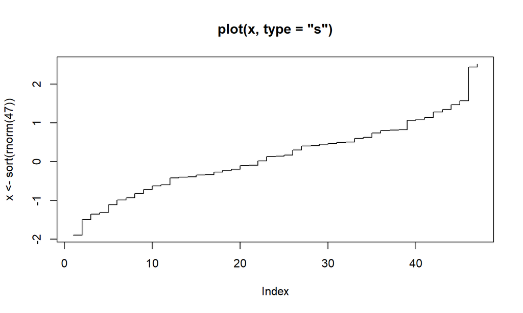

```r
#plot example of plot function
plot(x <- sort(rnorm(47)), type = "s", main = "plot(x, type = \"s\")")
```

## The Environment and History Pane (upper right)

### The History Tab

On the History tab you will see a history of all the commands you have sent to R console in the session.

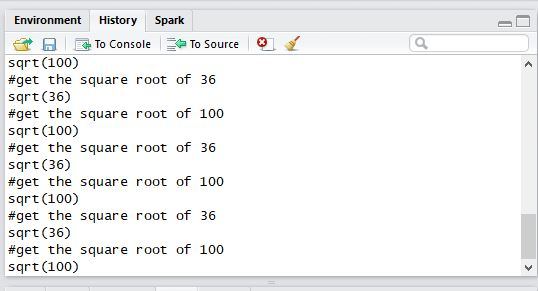

## The Environment Tab

Now let's click on the Environment tab.

[figure not shown]

You will see that R has created an object called "x." Where did this come from? **You** created this when you copied and ran code from the `plot` function example. **Objects are largely what make R, R.**

Earlier we used `sqrt` to calculate the square root of a number. Wouldn't it be nice to save the result to use for later? Let's do that by creating an object, `result`. Type the following into your script:

```r
#use sqrt function to calculate sqrt of 10 and store result in object called result
result<-sqrt(10)
```

You should see that the object appears in the section on the Environment tab labeled "Global Environment." A major part of your work involves creating objects.

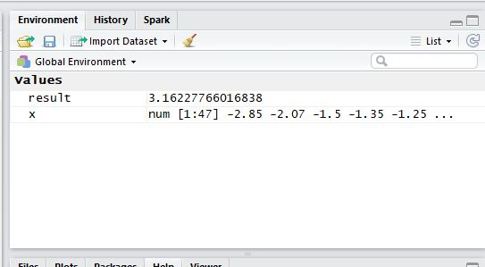

The objects stored in the Environment and History together make up the **workspace environment.**

When you close R, R brings up a window that asks whether you'd like to save the workspace image (a snapshot of the current contents in the environment).

[figure not shown]

As a good practice, rarely save the workspace if the code can be quickly re-run. It is easy to accumulate an unmanageable amount of data and objects.

## Some other things to note about the envrionment in RStudio:

1. Clear the environment by clicking the "clear" button (with the broom). You can also write `rm(list=ls())` in your script.
2. View the environment in your console by typing `ls()`.
3. Remove objects in the environment by using the `rm` function. For exampe, `rm(x)` will remove `x` from your environment.
4. You can save individual items of the workspace with the `save` function. For example, `save(x)` will save individual objects in the workspace.

## RStudio Settings

Now that you have a brief introduction to RStudio's panes let's look at the program's options where you can control settings such as font size, etc.

Go to **Tools | Global Options** and you'll see the following box:

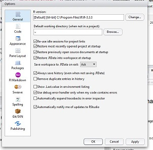

## There are some cool things here….

- General - look but don't touch…
- Code editing - make sure the soft wrap option is selected; this will ensure that lines of code are automatically wrapped so you don't have to press return when you get to the end of a line.
- Appearance (*this one is fun*)- choose a color scheme that works for you.
- Pane layout - use the default layout for the duration of this primer.
- Packages - make sure "enable packages pane"" is checked. We'll cover packages in the next chapter.
- Spelling - allows a spell-check of your files.